# Identify relevant expression profiles

David Badenas

12 nov. 2025

```r
library(ggplot2)
library(dplyr)
library(pheatmap)
library(RColorBrewer)
library(readr)
library(matrixStats)
library(edgeR)
library(GEOquery)
library(ggfortify)
```

# 1 BULK

## 1.1 Bulk gene expression (RNA-seq)

```r
setwd("C:/Users/david/OneDrive/Escritorio/Doctorado/Identify relevant expression profiles/Bulk RNAseq/")

expresion <- read.csv("proc_rnaseq.csv", header = TRUE, row.names = 1)
meta <- readRDS("meta.rds")
```

```r
dim(expresion)
```

```
## [1] 14313   117
```

### 1.1.1 Normal

```r
expresion_imputada <- apply(expresion, 1, function(x) {  #La funcion apply delvuelve una matriz traspuesta
  x[is.na(x)] <- mean(x, na.rm = TRUE)
  return(x)
})
```

Los valores NA se sustituyen por la media del gen, esto evita que el PCA falle.

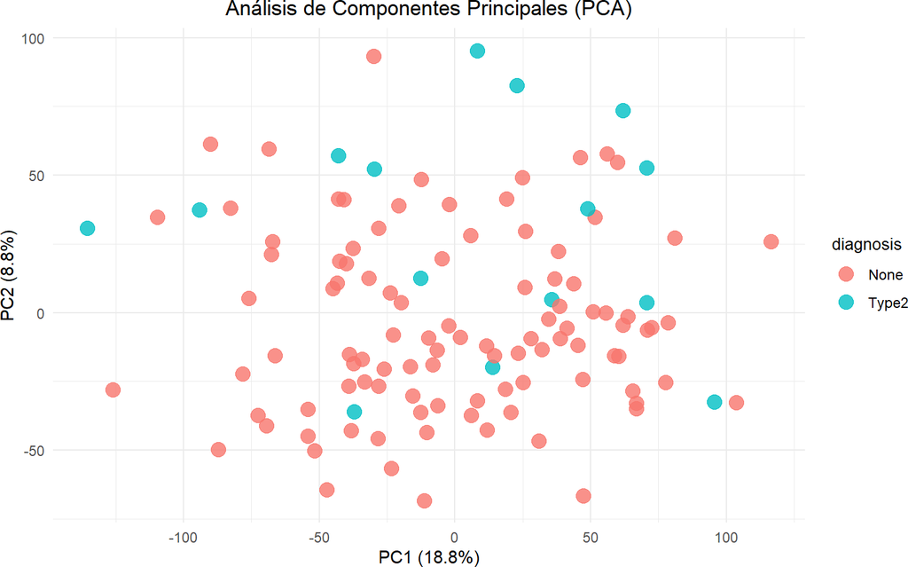

```r
pca_res <- prcomp(expresion_imputada, scale. = TRUE)


var_explicada <- pca_res$sdev^2 / sum(pca_res$sdev^2) * 100

pca_df <- data.frame(pca_res$x[, 1:2],
                     Muestra = rownames(pca_res$x))
meta$Muestra <- meta$record_id

pca_defi <- inner_join(pca_df, meta, by = "Muestra")

ggplot(pca_defi, aes(x = PC1, y = PC2)) +
  geom_point(aes(color = diagnosis), size = 4, alpha = 0.8) +
  xlab(paste0("PC1 (", round(var_explicada[1], 1), "%)")) +
  ylab(paste0("PC2 (", round(var_explicada[2], 1), "%)")) +
  ggtitle("Análisis de Componentes Principales (PCA)") +
  theme_minimal() +
  theme(
    plot.title = element_text(hjust = 0.5),
    legend.title = element_text(size = 10),
    legend.text = element_text(size = 9)
  )
```

### 1.1.2 Con los 1000 genes más variables

Los genes con baja variabilidad son genes housekeeping, esto genes provocan “ruido”. Al quedarme solo con los genes más variables, refuerzo las señales biológicas reales que diferencian grupos de pacientes.

Ordena los genes por varianza y selecciona los más variables (los que mejor discriminan entre muestras).

```r
var_genes <- apply(expresion, 1, var, na.rm = TRUE)

top_genes <- names(sort(var_genes, decreasing = TRUE))[1:1000]
expresion_top <- expresion[top_genes, ]
```

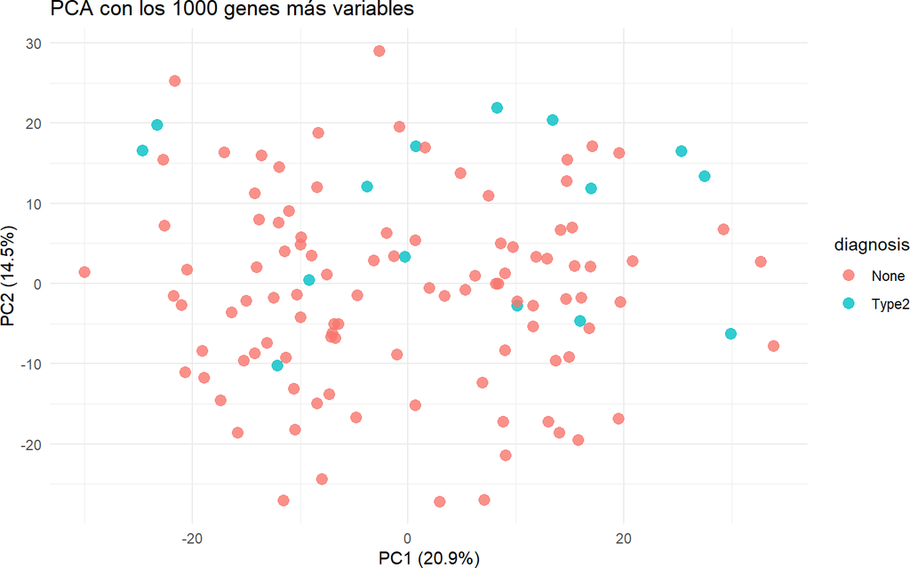

```r
expresion_top <- t(apply(expresion[top_genes, ], 1, function(x) {
  x[is.na(x)] <- mean(x, na.rm = TRUE)
  x
}))
expresion_top <- as.data.frame(expresion_top)
expresion_top <- t(expresion_top)

pca_res <- prcomp(expresion_top, scale. = TRUE)
var_explicada <- pca_res$sdev^2 / sum(pca_res$sdev^2) * 100

pca_df <- data.frame(pca_res$x[, 1:2], Muestra = rownames(pca_res$x))
pca_defi <- inner_join(pca_df, meta, by = "Muestra")

ggplot(pca_defi, aes(PC1, PC2, color = diagnosis)) +
  geom_point(size = 3, alpha = 0.8) +
  xlab(paste0("PC1 (", round(var_explicada[1], 1), "%)")) +
  ylab(paste0("PC2 (", round(var_explicada[2], 1), "%)")) +
  ggtitle("PCA con los 1000 genes más variables") +
  theme_minimal()
```

### 1.1.3 Aplicando filtrado de los datos

- Substantial expression –> Se seleccionan genes cuya expresión máxima ≥ 2, esto elimina los genes con niveles de expresión extremadamente bajos. “Para cada gen mirar si por lo menos en 1 paciente el nivel de expresión es mayor o igual a 2”
- High expression –> Se seleccionan genes con expresión máxima aún mayor, enfocado en los genes más activos. “Para cada gen mirar si por lo menos en 1 paciente el nivel de expresión es mayor o igual a 100”

```r
expresion_imputada <- t(apply(expresion, 1, function(x) {
  x[is.na(x)] <- mean(x, na.rm = TRUE)
  x
}))


substantial_expression <- expresion_imputada[rowMaxs(as.matrix(expresion_imputada), na.rm = TRUE) >= 2, ]
high_expression <- expresion_imputada[rowMaxs(as.matrix(expresion_imputada), na.rm = TRUE) >= 100, ]

cat("Dimensiones de substantial_expression:", dim(substantial_expression), "\n")
```

```
## Dimensiones de substantial_expression: 10452 117
```

```r
cat("Dimensiones de high_expression:", dim(high_expression), "\n")
```

```
## Dimensiones de high_expression: 0 117
```

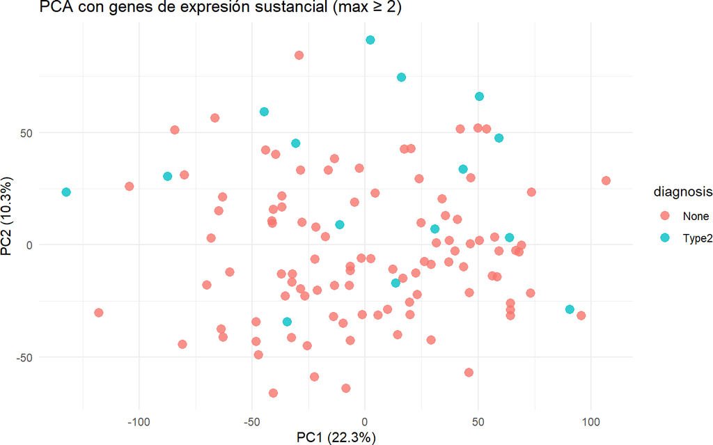

```r
#No tenemos genes de expresión máxima


pca_substantial_expression <- log2(t(substantial_expression) + 1)


pca_substantial_expression[!is.finite(as.matrix(pca_substantial_expression))] <- 0



pca_substantial <- prcomp(pca_substantial_expression, scale. = TRUE)



var_substantial <- pca_substantial$sdev^2 / sum(pca_substantial$sdev^2) * 100


pca_sub_df <- data.frame(pca_substantial$x[, 1:2], Muestra = rownames(pca_substantial$x))


pca_sub_defi <- inner_join(pca_sub_df, meta, by = "Muestra")



ggplot(pca_sub_defi, aes(PC1, PC2, color = diagnosis)) +
  geom_point(size = 3, alpha = 0.8) +
  xlab(paste0("PC1 (", round(var_substantial[1], 1), "%)")) +
  ylab(paste0("PC2 (", round(var_substantial[2], 1), "%)")) +
  ggtitle("PCA con genes de expresión sustancial (max ≥ 2)") +
  theme_minimal()
```

## 1.2 Pseudobulk gene expression (Alpha cells)

```r
setwd("C:/Users/david/OneDrive/Escritorio/Doctorado/Identify relevant expression profiles/Pseudobulk RNAseq (Alpha cells)/")

expresion <- readRDS("proc_pbrna_Alpha.rds")
meta <- readRDS("donor.rds")
```

```r
expresion <- expresion[, -1]
```

```r
dim(expresion)
```

```
## [1] 16874    47
```

### 1.2.1 Normal

```r
expresion_imputada <- apply(expresion, 1, function(x) {
  x[is.na(x)] <- mean(x, na.rm = TRUE)
  return(x)
})
```

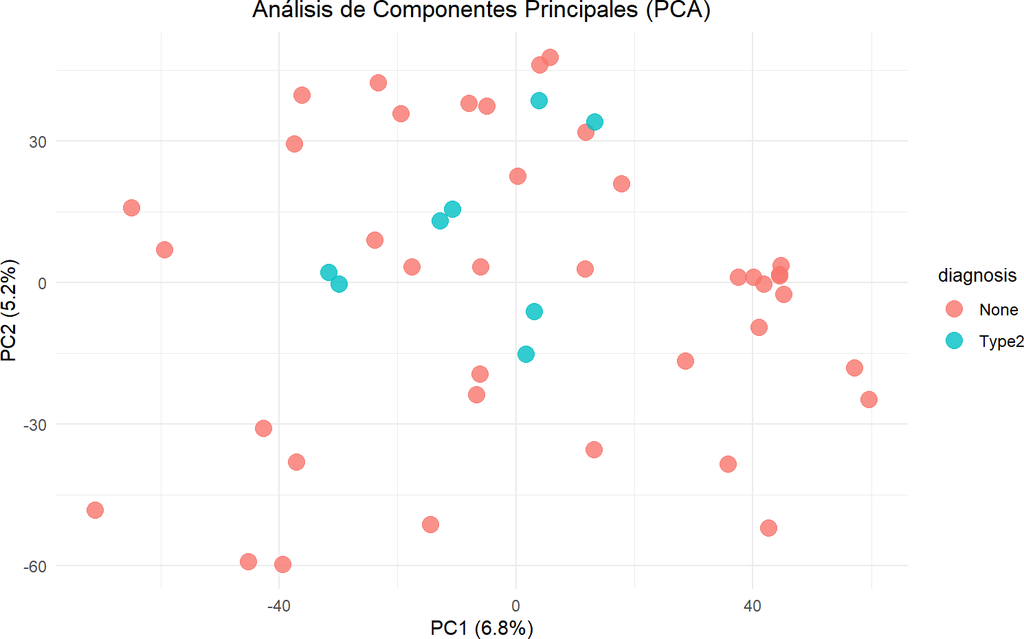

```r
pca_res <- prcomp(expresion_imputada, scale. = TRUE)


var_explicada <- pca_res$sdev^2 / sum(pca_res$sdev^2) * 100

pca_df <- data.frame(pca_res$x[, 1:2],
                     Muestra = rownames(pca_res$x))
meta$Muestra <- meta$record_id

pca_defi <- inner_join(pca_df, meta, by = "Muestra")

ggplot(pca_defi, aes(x = PC1, y = PC2)) +
  geom_point(aes(color = diagnosis), size = 4, alpha = 0.8) +
  xlab(paste0("PC1 (", round(var_explicada[1], 1), "%)")) +
  ylab(paste0("PC2 (", round(var_explicada[2], 1), "%)")) +
  ggtitle("Análisis de Componentes Principales (PCA)") +
  theme_minimal() +
  theme(
    plot.title = element_text(hjust = 0.5),
    legend.title = element_text(size = 10),
    legend.text = element_text(size = 9)
  )
```

### 1.2.2 Con los 1000 genes más variables

```r
var_genes <- apply(expresion, 1, var, na.rm = TRUE)
top_genes <- order(var_genes, decreasing = TRUE)[1:1000]
expresion_top <- expresion[top_genes, ]
```

```r
expresion_top <- t(apply(expresion_top, 1, function(x) {
  x[is.na(x)] <- mean(x, na.rm = TRUE)
  x
}))
```

```r
expresion_top <- as.data.frame(expresion_top)
expresion_top <- t(expresion_top)
```

```r
pca_res <- prcomp(expresion_top, scale. = TRUE)
var_explicada <- pca_res$sdev^2 / sum(pca_res$sdev^2) * 100
```

```r
pca_df <- data.frame(pca_res$x[, 1:2], Muestra = rownames(pca_res$x))
meta$Muestra <- meta$record_id
pca_defi <- inner_join(pca_df, meta, by = "Muestra")
```

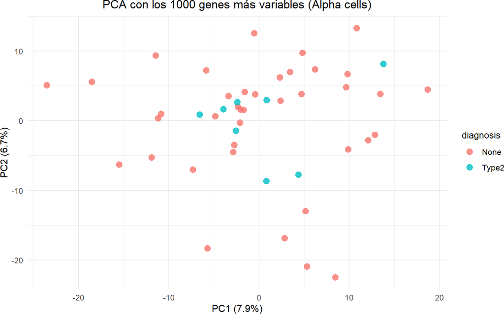

```r
ggplot(pca_defi, aes(PC1, PC2, color = diagnosis)) +
  geom_point(size = 3, alpha = 0.8) +
  xlab(paste0("PC1 (", round(var_explicada[1], 1), "%)")) +
  ylab(paste0("PC2 (", round(var_explicada[2], 1), "%)")) +
  ggtitle("PCA con los 1000 genes más variables (Alpha cells)") +
  theme_minimal() +
  theme(
    plot.title = element_text(hjust = 0.5),
    legend.title = element_text(size = 10),
    legend.text = element_text(size = 9)
  )
```

### 1.2.3 Aplicando filtrado de los datos

```r
expresion_imputada <- t(apply(expresion, 1, function(x) {
  x[is.na(x)] <- mean(x, na.rm = TRUE)
  x
}))
```

```r
substantial_expression <- expresion_imputada[rowMaxs(as.matrix(expresion_imputada), na.rm = TRUE) >= 2, ]
high_expression <- expresion_imputada[rowMaxs(as.matrix(expresion_imputada), na.rm = TRUE) >= 100, ]
```

```r
dim(substantial_expression)
```

```
## [1] 15404    47
```

```r
dim(high_expression)
```

```
## [1]  0 47
```

```r
pca_substantial_expression <- log2(t(substantial_expression) + 1)
pca_substantial_expression[!is.finite(as.matrix(pca_substantial_expression))] <- 0

pca_substantial <- prcomp(pca_substantial_expression, scale. = TRUE)
var_substantial <- pca_substantial$sdev^2 / sum(pca_substantial$sdev^2) * 100
```

```r
pca_sub_df <- data.frame(pca_substantial$x[, 1:2], Muestra = rownames(pca_substantial$x))
meta$Muestra <- meta$record_id
pca_sub_defi <- inner_join(pca_sub_df, meta, by = "Muestra")
```

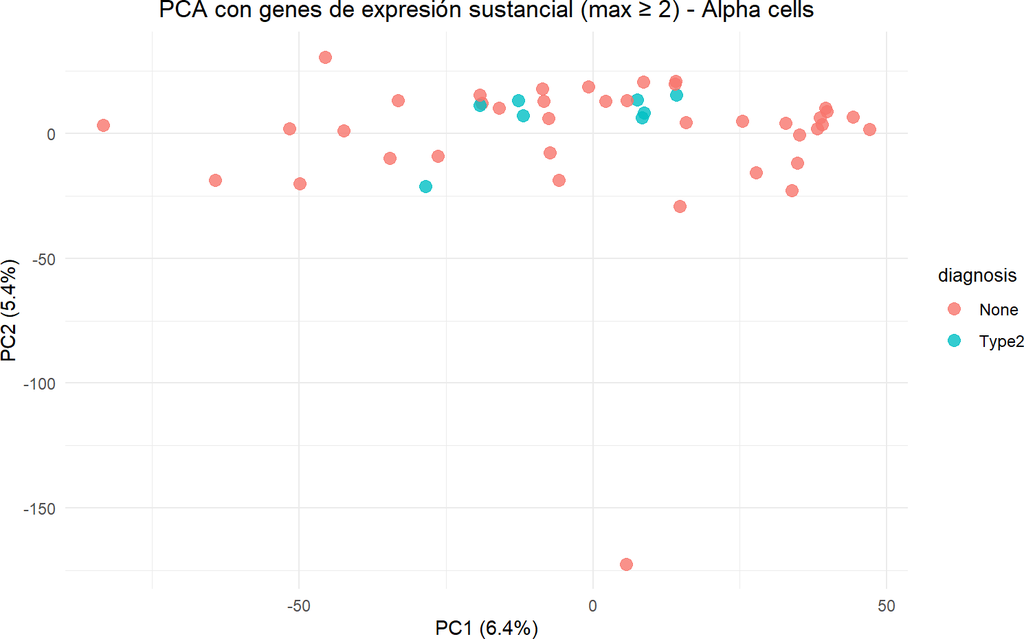

```r
ggplot(pca_sub_defi, aes(PC1, PC2, color = diagnosis)) +
  geom_point(size = 3, alpha = 0.8) +
  xlab(paste0("PC1 (", round(var_substantial[1], 1), "%)")) +
  ylab(paste0("PC2 (", round(var_substantial[2], 1), "%)")) +
  ggtitle("PCA con genes de expresión sustancial (max ≥ 2) - Alpha cells") +
  theme_minimal() +
  theme(
    plot.title = element_text(hjust = 0.5),
    legend.title = element_text(size = 10),
    legend.text = element_text(size = 9)
  )
```

## 1.3 Pseudobulk gene expression (Alpha cells)

Hay menos de 10 pacientes.

# 2 Single cell

## 2.1 Single-cell mRNA-regulation analysis reveals cell type-specific mechanisms of type 2 diabetes

### 2.1.1 GSE153855

```r
gseid<-"GSE153855"
gse<- getGEO(gseid, GSEMatrix=TRUE)[[1]]
```

```
## Found 1 file(s)
```

```
## GSE153855_series_matrix.txt.gz
```

```r
pheno <- pData(gse)
dim(pheno)
```

```
## [1] 11 41
```

```r
setwd("C:/Users/david/OneDrive/Escritorio/Doctorado/Identify relevant expression profiles/")

gseSupp <- getGEOSuppFiles(gseid, makeDirectory = TRUE)

# Intuyo que los datos de annotation y count estan ordenados, es decir el primero de annotation es el primero de counts
annotation <- read.delim("GSE153855/GSE153855_Cell_annotation.txt.gz")
counts<- read.delim("GSE153855/GSE153855_Expression_counts_HQ_allsamples.txt.gz", header = FALSE)
dim(counts)
```

```
## [1] 30558  3384
```

```r
dim(annotation)
```

```
## [1] 3385    3
```

```r
colnames(counts)[-1] <- annotation$Donor
countsM <- as.matrix(counts)

dim(countsM)
```

```
## [1] 30558  3384
```

```r
keep <- rowSums(countsM > 10) >= 4
countsF <- countsM[keep,]
dim(countsF)
```

```
## [1]  300 3384
```

Normalización usando TMM (Trimmed Mean of M-values)

```r
rownames(countsF) <- countsF[, 1]
countsF_num <- countsF[, -1]

countsF_num <- as.matrix(countsF_num)
mode(countsF_num) <- "numeric"

dge <- DGEList(counts = countsF_num)
```

```
## Repeated column names found in count matrix
```

```r
dge <- calcNormFactors(dge, method = "TMM")
countsTMM <- cpm(dge, log = TRUE)
countsTMMnoLog <- cpm(dge, log = FALSE)

dim(countsTMM)
```

```
## [1]  300 3383
```

#### 2.1.1.1 Normal

```r
pca_res <- prcomp(t(countsTMM), scale. = TRUE)
pca_df <- data.frame(pca_res$x[, 1:2])
var_explicada <- pca_res$sdev^2 / sum(pca_res$sdev^2) * 100
pca_df <- data.frame(pca_res$x[,1:2], Muestra = colnames(countsTMM))
```

```r
pca_df$Sample <- rownames(pca_df)
pca_df$Donor <- gsub("\\..*$", "", pca_df$Sample)
annotation_clean <- annotation %>%
  filter(Donor != "")
nrow(annotation_clean)
```

```
## [1] 3383
```

```r
nrow(pca_df)
```

```
## [1] 3383
```

```r
pca_df$CellType <- annotation_clean$CellType
pca_df$Disease  <- annotation_clean$Disease
```

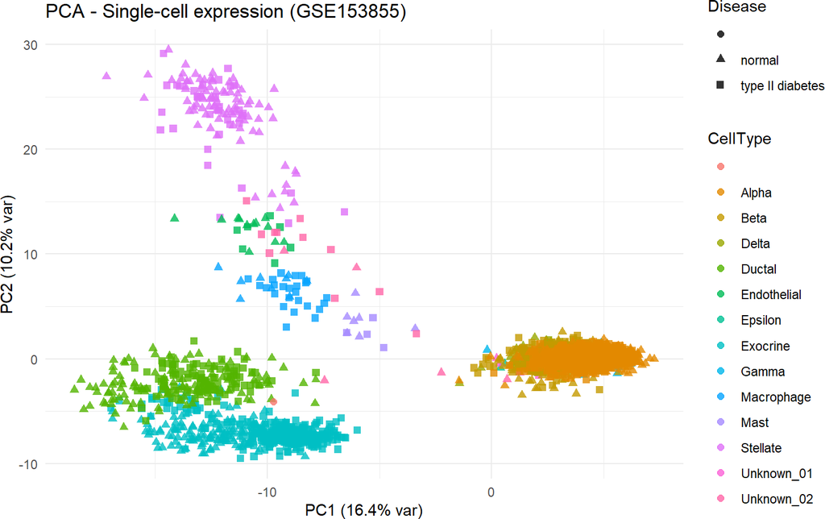

```r
ggplot(pca_df, aes(x = PC1, y = PC2, color = CellType, shape = Disease)) +
  geom_point(size = 2, alpha = 0.8) +
  theme_minimal() +
  labs(
    title = "PCA - Single-cell expression (GSE153855)",
    x = paste0("PC1 (", round(summary(pca_res)$importance[2, 1] * 100, 1), "% var)"),
    y = paste0("PC2 (", round(summary(pca_res)$importance[2, 2] * 100, 1), "% var)")
  ) +
  theme(legend.position = "right")
```

```r
gene_means <- rowMeans(countsTMMnoLog)

top_genes <- names(sort(gene_means, decreasing = TRUE))[1:300]
countsTMM_top <- countsTMM[top_genes, ]
```

```r
pca_res_top <- prcomp(t(countsTMM_top), scale. = TRUE)
var_explicada_top <- pca_res_top$sdev^2 / sum(pca_res_top$sdev^2) * 100

pca_df_top <- data.frame(pca_res_top$x[,1:2], Muestra = colnames(countsTMM_top))

pca_df_top$CellType <- annotation_clean$CellType
pca_df_top$Disease  <- annotation_clean$Disease
```

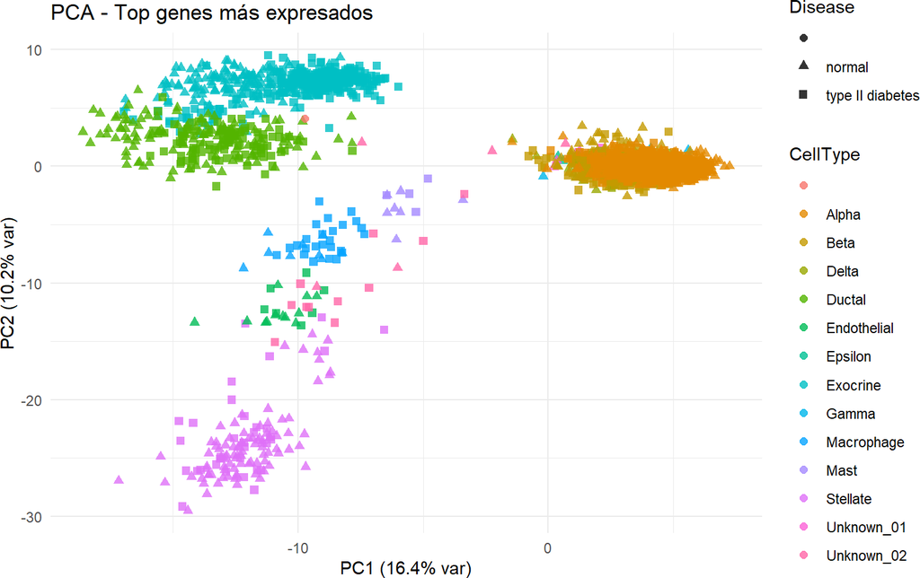

```r
ggplot(pca_df_top, aes(x = PC1, y = PC2, color = CellType, shape = Disease)) +
  geom_point(size = 2, alpha = 0.8) +
  theme_minimal() +
  labs(
    title = "PCA - Top genes más expresados",
    x = paste0("PC1 (", round(summary(pca_res_top)$importance[2,1]*100,1), "% var)"),
    y = paste0("PC2 (", round(summary(pca_res_top)$importance[2,2]*100,1), "% var)")
  ) +
  theme(legend.position = "right")
```

###GSE214517 Estos datos ya están normalizados.

```r
gseid_1<-"GSE214517"
gse_1<- getGEO(gseid_1, GSEMatrix=TRUE)[[1]]
```

```
## Found 1 file(s)
```

```
## GSE214517_series_matrix.txt.gz
```

```r
pheno <- pData(gse_1)
dim(pheno)
```

```
## [1] 2785   39
```

```r
setwd("C:/Users/david/OneDrive/Escritorio/Doctorado/Identify relevant expression profiles/")
gseSupp <- getGEOSuppFiles(gseid_1, makeDirectory = TRUE)

counts<- read.delim("GSE214517/GSE214517_rpkms.txt.gz", header = TRUE)
dim(counts)
```

```
## [1] 22281  2786
```

```r
colnames(counts)[-1] <- pheno$title
countsM <- as.matrix(counts)

dim(countsM)
```

```
## [1] 22281  2786
```

```r
keep <- rowSums(countsM > 10) >= 4
countsF <- countsM[keep,]
dim(countsF)
```

```
## [1] 21365  2786
```

```r
rownames(countsF) <- countsF[, 1]
countsF_num <- countsF[, -1]

countsF_num <- as.matrix(countsF_num)
mode(countsF_num) <- "numeric"

counts_log <- log2(countsF_num + 1)
```

#### 2.1.1.3 Normal

```r
pca_res <- prcomp(t(counts_log), scale. = TRUE)
pca_df <- data.frame(pca_res$x[, 1:2])
```

```r
pca_df$title <- rownames(pca_df)

pca_merged <- inner_join(pca_df, pheno, by = "title")
```

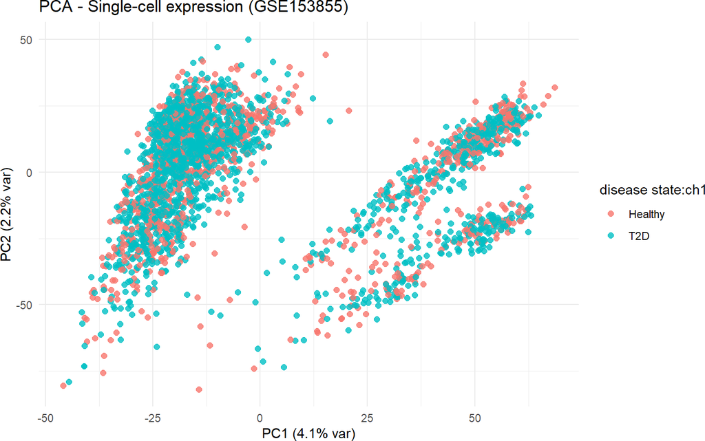

```r
ggplot(pca_merged, aes(x = PC1, y = PC2, color = `disease state:ch1`)) +
  geom_point(size = 2, alpha = 0.8) +
  theme_minimal() +
  labs(
    title = "PCA - Single-cell expression (GSE153855)",
    x = paste0("PC1 (", round(summary(pca_res)$importance[2, 1] * 100, 1), "% var)"),
    y = paste0("PC2 (", round(summary(pca_res)$importance[2, 2] * 100, 1), "% var)")
  ) +
  theme(legend.position = "right")
```

```r
gene_means <- rowMeans(counts_log)
top_genes <- names(sort(gene_means, decreasing = TRUE))[1:300]
counts_log_top <- counts_log[top_genes, ]
```

```r
pca_res_top <- prcomp(t(counts_log_top), scale. = TRUE)

var_explicada_top <- pca_res_top$sdev^2 / sum(pca_res_top$sdev^2) * 100

pca_df_top <- data.frame(pca_res_top$x[,1:2], Muestra = colnames(counts_log_top))

pca_df_top$Disease <- pca_merged$`disease state:ch1`
```

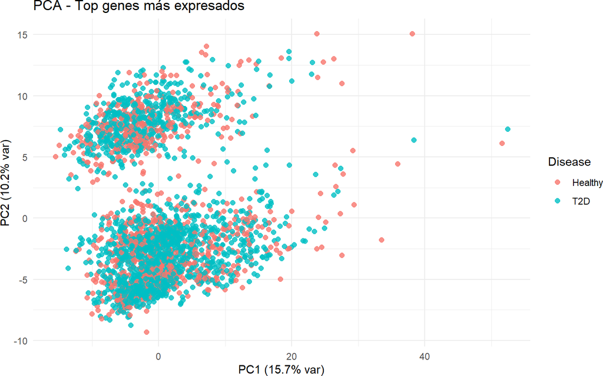

```r
ggplot(pca_df_top, aes(x = PC1, y = PC2, color = Disease)) +
  geom_point(size = 2, alpha = 0.8) +
  theme_minimal() +
  labs(
    title = "PCA - Top genes más expresados",
    x = paste0("PC1 (", round(summary(pca_res_top)$importance[2,1]*100,1), "% var)"),
    y = paste0("PC2 (", round(summary(pca_res_top)$importance[2,2]*100,1), "% var)")
  ) +
  theme(legend.position = "right")
```

## 2.2 Functional, metabolic and transcriptional maturation of human pancreatic islets derived from stem cells

### 2.2.1 GSE167880

En los metadatos no aparece si tiene T2D o no, ademas no está la matriz de gene expression.

```r
gseid_2<-"GSE167880"
gse_2<- getGEO(gseid_2, GSEMatrix=TRUE)[[1]]
```

```
## Found 1 file(s)
```

```
## GSE167880_series_matrix.txt.gz
```

```r
pheno <- pData(gse_2)
dim(pheno)
```

```
## [1] 18 50
```